# Storm Analysis

## Synopsis

Storms and other severe weather events can cause both public health and economic problems for communities and municipalities. Many severe events can result in fatalities, injuries, and property damage, and preventing such outcomes to the extent possible is a key concern.

This project involves exploring the U.S. National Oceanic and Atmospheric Administration’s (NOAA) storm database. This database tracks characteristics of major storms and weather events in the United States, including when and where they occur, as well as estimates of any fatalities, injuries, and property damage.

## Data

The data for this assignment come in the form of a comma-separated-value file compressed via the bzip2 algorithm to reduce its size. You can download the file from the course web site:

- [Storm Data](https://d396qusza40orc.cloudfront.net/repdata%2Fdata%2FStormData.csv.bz2) [47Mb]

There is also some documentation of the database available. Here you will find how some of the variables are constructed/defined.

- National Weather Service [Storm Data Documentation](https://d396qusza40orc.cloudfront.net/repdata%2Fpeer2_doc%2Fpd01016005curr.pdf)
- National Climatic Data Center Storm Events [FAQ](https://d396qusza40orc.cloudfront.net/repdata%2Fpeer2_doc%2FNCDC%20Storm%20Events-FAQ%20Page.pdf)

The events in the database start in the year 1950 and end in November 2011. In the earlier years of the database there are generally fewer events recorded, most likely due to a lack of good records. More recent years should be considered more complete.

## Data Processing

Download the file

```r
download.file("https://d396qusza40orc.cloudfront.net/repdata%2Fdata%2FStormData.csv.bz2", destfile = "StormData.csv.bz2", method = "curl")
```

Read the data from the file

```r
stormData <- read.csv("StormData.csv.bz2")
```

Load the required libraries

```r
library(dplyr)
library(ggplot2)
library(gridExtra)
```

## Calculations

The first calculation will be how many injuries occur by each event.

```r
injuries_by_event <- aggregate(INJURIES ~ EVTYPE, data = stormData, sum)
injuries_by_event <- injuries_by_event[order(injuries_by_event$INJURIES, decreasing = TRUE),]
```

Here are the top 10 events that cause injuries.

```r
top_injuries <- injuries_by_event[1:10, ]
top_injuries
```

```
##                EVTYPE INJURIES
## 834           TORNADO    91346
## 856         TSTM WIND     6957
## 170             FLOOD     6789
## 130    EXCESSIVE HEAT     6525
## 464         LIGHTNING     5230
## 275              HEAT     2100
## 427         ICE STORM     1975
## 153       FLASH FLOOD     1777
## 760 THUNDERSTORM WIND     1488
## 244              HAIL     1361
```

The next calculation is how many deaths occur by each event.

```r
deaths_by_event <- aggregate(FATALITIES ~ EVTYPE, data = stormData, sum)
deaths_by_event <- deaths_by_event[order(deaths_by_event$FATALITIES, decreasing = TRUE), ]
```

Here are the top 10 events that cause deaths.

```r
top_deaths <- deaths_by_event[1:10, ]
top_deaths
```

```
##             EVTYPE FATALITIES
## 834        TORNADO       5633
## 130 EXCESSIVE HEAT       1903
## 153    FLASH FLOOD        978
## 275           HEAT        937
## 464      LIGHTNING        816
## 856      TSTM WIND        504
## 170          FLOOD        470
## 585    RIP CURRENT        368
## 359      HIGH WIND        248
## 19       AVALANCHE        224
```

The last calculation is how much damage is done to property and crops by each event.

```r
economic_by_event <- aggregate(PROPDMG + CROPDMG ~ EVTYPE, data = stormData, sum)
economic_by_event <- economic_by_event[order(economic_by_event$`PROPDMG + CROPDMG`, decreasing = TRUE), ]
```

Here are the top 15 events that cause the most damage to property and crops.

```r
top_economic <- economic_by_event[1:15, ]
top_economic
```

```
##                 EVTYPE PROPDMG + CROPDMG
## 834            TORNADO        3312276.68
## 153        FLASH FLOOD        1599325.05
## 856          TSTM WIND        1445168.21
## 244               HAIL        1268289.66
## 170              FLOOD        1067976.36
## 760  THUNDERSTORM WIND         943635.62
## 464          LIGHTNING         606932.39
## 786 THUNDERSTORM WINDS         464978.11
## 359          HIGH WIND         342014.77
## 972       WINTER STORM         134699.58
## 310         HEAVY SNOW         124417.71
## 957           WILDFIRE          88823.54
## 427          ICE STORM          67689.62
## 676        STRONG WIND          64610.71
## 290         HEAVY RAIN          61964.94
```

## Results

1. Across the United States, which types of events are most harmful with respect to population health?

These two bargraphs show which events have caused the most injuries and the most deaths to human. Clearly, tornadoes cause the most injuries and most deaths to humans.

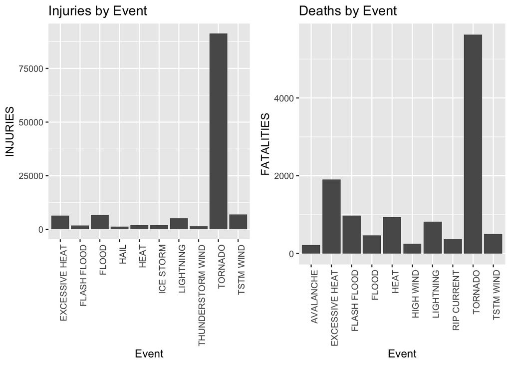

```r
plot_injuries <- ggplot(top_injuries, aes(EVTYPE, INJURIES)) +
        geom_bar(stat = "identity") +
        theme(axis.text.x = element_text(angle = 90, hjust = 1)) +
        ggtitle("Injuries by Event") +
        xlab("Event")

plot_deaths <- ggplot(top_deaths, aes(EVTYPE, FATALITIES)) +
        geom_bar(stat = "identity") +
        theme(axis.text.x = element_text(angle = 90, hjust = 1)) +
        ggtitle("Deaths by Event") +
        xlab("Event")

grid.arrange(plot_injuries, plot_deaths, nrow = 1)
```

2. Across the United States, which types of events have the greatest economic consequences?

This bargraph shows how much economic damage each event has on property and crops. Just like the previous question, tornadoes cause the most economic damage.

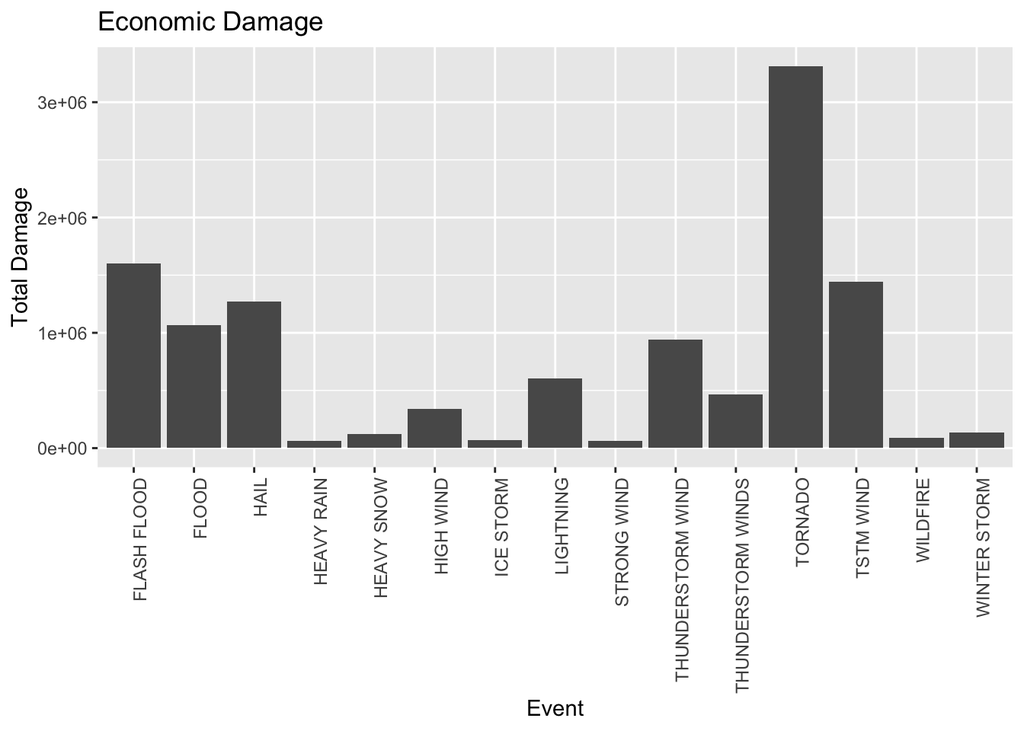

```r
ggplot(top_economic, aes(EVTYPE, `PROPDMG + CROPDMG`)) +
        geom_bar(stat = "identity") +
        theme(axis.text.x = element_text(angle = 90, hjust = 1)) +
        ggtitle("Economic Damage") +
        xlab("Event") +
        ylab("Total Damage")
```